# Moodle Tasks

## Задача 5

За данните `rat` от пакета `UsingR` постройте $96\%$ доверителен интервал за очакването.

### Решение

Първо трябва да проверим дали данните са номрално разпределени

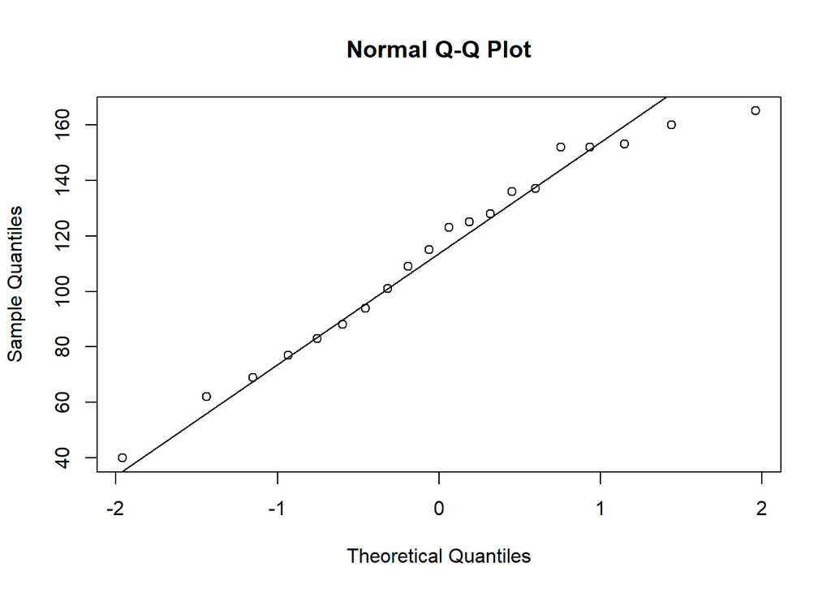

```r
> qqnorm(rat)
> qqline(rat)
```

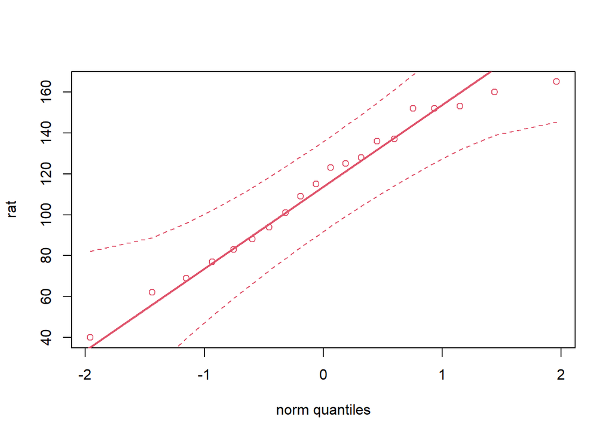

```r
> library(StatDA)
Warning: package 'StatDA' was built under R version 4.0.3
Loading required package: sgeostat
Warning: package 'sgeostat' was built under R version 4.0.3
Registered S3 method overwritten by 'geoR':
  method         from
  plot.variogram sgeostat
> qqplot.das(rat, "norm")
```

```r
> shapiro.test(rat)

    Shapiro-Wilk normality test

data:  rat
W = 0.96134, p-value = 0.571
```

Както виждаме от графиките и от $p-value = 0.571 > 0.05 = \alpha$ можем да допуснем, че данните ни са нормално разпредлени.

Данните са малко.

```r
> length(rat)
[1] 20
```

Имаме $20$ наблюдения, но видяхме, че може да допуснем, че са от нормално разпределение. $\sigma$ е неизвестно. Поради това можем да използваме `t.test`

```r
> t.test(rat, conf.level = 0.96)

    One Sample t-test

data:  rat
t = 14.176, df = 19, p-value = 1.48e-11
alternative hypothesis: true mean is not equal to 0
96 percent confidence interval:
  95.80624 131.09376
sample estimates:
mean of x
   113.45
```

## Задача 6

При провеждане на анкета $87$ от $150$ анкетирани са отговорили, че са използвали даден продукт. Постройте $92\%$ доверителен интервал за броя на хората използвали продукта.

### Решение

Можем да използваме приближението с нормалното

```r
> n <- 150
> phat <- 87 / 150
> alpha <- 0.08
> SE <- sqrt((phat * (1 - phat)) / n)
> zstar <- qnorm(1 - alpha/2)
> ci <- phat + c(-zstar*SE, zstar*SE)
```

Тогава доверителния интервал за броя на хората използвали продукта е

```r
> ci*150
[1] 76.4174 97.5826
```

или

```r
> ci <- prop.test(87, 150, conf.level = 0.92)
> ci$conf.int*150
[1] 75.77986 97.71710
attr(,"conf.level")
[1] 0.92
```

Или да използваме биномното разпределение

```r
> n <- 150
> phat <- 87 / 150
> alpha <- 0.08
> c(qbinom(alpha / 2, n, phat), qbinom(1 - alpha / 2, n, phat))
[1] 76 98
```

или

```r
> ci <- binom.test(87, 150, conf.level = 0.92)
> ci$conf.int*150
[1] 75.79584 97.80451
attr(,"conf.level")
[1] 0.92
```